# 生成AI時代に認知行動療法研究で問うべきことは？

専修大学 国里愛彦

## 自己紹介

- 国里愛彦（くにさと よしひこ）
- 専修大学人間科学部心理学科 教授
- 専門：計算論的精神医学、認知行動療法
- 関心：うつや不安の発生・維持メカニズム、心理療法の作用メカニズム、個性記述
- COI開示：本発表に関する開示すべき利益相反はありません

## 生成AIを認知行動療法研究に使う

- 生成AIは、世界中のテキスト（画像、動画なども）を用いて学習したモデルなので、人間が行う行動や認知過程を模倣できる可能性がある。
- 生成AIによって、どのように研究が変わるのか？（既に変わっているのか）

# 生成AIを研究に用いることのライトサイド

## 論文の検索

- 論文の検索は、特化型サービス(Scispace, Perplexityなど)もあるが、chatGPTやGeminiなど汎用サービスの機能強化(Deep Research)で十分になりつつある。
- Deep Researchが完璧な網羅性を持っているわけではないが（オープンアクセスな情報に偏りがち）、ざっくり目星をつけるには十分。
- 医療情報などについては特に注意が必要だが（ハルシネーションは減っているがゼロではない）、心理療法のエビデンスの探索にも十分使える。

## 論文内容の読み込み

- Deep Researchは、論文をリスト化した上で、要約なども生成できる。
- Readableは生成AIというよりもPDFの翻訳サービスだが、PDFのフォーマットを維持して、翻訳してくれる。
- Scispaceは、論文PDFをアップロードして、質問形式で内容を読み込める。

## NotebookLM

- GoogleのNotebookLMは、ソースを読み込ませると、音声・動画解説、マインドマップ、レポート、フラッシュカード、テストを生成できる（もちろん質問も可能）
- Omizu and Kunisato(2025)のPDFから作った動画

[video not shown]

## 研究で使うマテリアルの作成

- 認知行動療法研究で使う文章マテリアルの生成（質問紙の項目、実験課題の説明・教示・文章刺激など）
- 画像・動画刺激の生成（→ Geminiで抑うつ気分の誘導に使えそうな画像を生成）

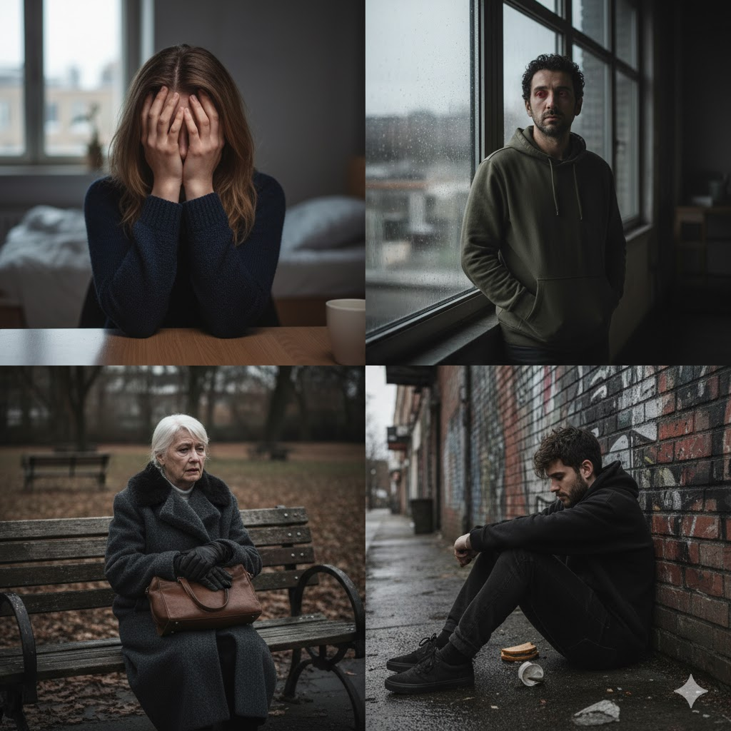

## 研究で使うプログラミング補助

- 生成AIはR, Python, javaScriptなどのコード生成も得意
- オンライン調査用のjsPsychのコードも生成可能（→）

[interactive chart not shown]

## 論文の執筆補助

- 非ネイティブは様々なコストを負っており、適切なAIツールの利用が必要(Amano et al. 2023)
- 生成AIは著者になれないが、ドラフト・校正などで使える(用いた場合は明示)

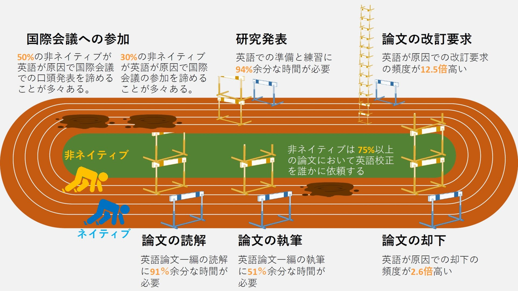

## 生成AIによる論文作成Tips

- [「医学英語論文をAI(ChatGPT/Claude/Gemini)で作成する方法」](https://note.com/genkaijokyo/n/nb3992750a49a)は非常に多くのTipsがまとまっており、オススメ（しかも随時更新される）

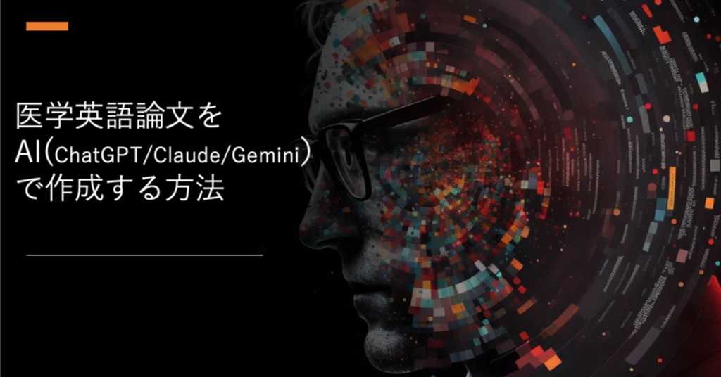

## 生成AIによるスライド作成

- GeminiがGoogleスライドにエクスポートできるスライド作成機能を追加（10/28）
- 「この論文PDFを基にスライドを作成してください。フォントサイズは大きめにしてください。」などの指示でスライドを生成可能

## LLMを活用した研究：質問紙開発

- LLMを用いて特定の構成概念を測る質問項目を生成し、さらに項目の類似度から洗練化(因子分析に類似)させる方法も提案されている(Russell-Lasalandra, Christensen, and Golino 2024)
- 質問紙の開発プロセスの効率化、一部自動化ができる。

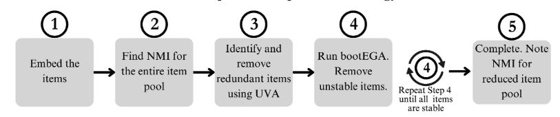

## LLMを活用した研究：文章の解釈

- 埋め込み技術(Embedding)を用いることで、文章の意味ネットワークをつくって評価することもできる(Golino 2025)
- 生成AIを用いることで、自然な状況で得られる自然言語について定量的に扱うことができるようになる。

> Golino-sanの新着プレプリント！  
> ネットワークの圧縮性の指標としてコルモゴロフ複雑性を使って、自然言語における抽象度が高い文章はコルモゴロフの複雑性は低くなる（情報を圧縮された構造を持つ）ことを示されています。幅広く応用できる手法と思います。 https://t.co/qCO8fq3OmD

> — Yoshihiko Kunisato/国里愛彦 ((**KunisatoY?**)) [October 30, 2025](https://twitter.com/KunisatoY/status/1984047143666266203?ref_src=twsrc%5Etfw)

# 生成AIを研究に用いることのダークサイド

## 生成AIにフレームを与える難しさ

- 人間がフレームを与えなくても適切に動作することも増えてきた
- ただ、複雑な内容を扱う場合、適切なフレームを与えないと動作しないことも

→ 結局、使う人間の理解・スキルがボトルネックに

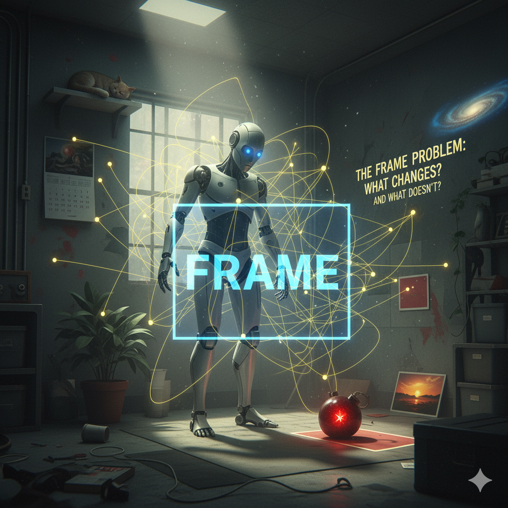

## 研究に関する能力低下

- 英語の論文を読んだり、書いたりするのが随分と簡単になってきた。
- しかし、人間の基礎的な能力が低下している可能性もある（英語力、数理的な問題理解力の低下など）
- 生成AIによって、能力の底上げができるが、皆が生成AIを使った時に差が出るのはその人の持っている知識や能力では？

## 生成AIによる論文が溢れかえる

- 生成AIで簡単にサーベイ論文を書けるので、大量に生成・投稿され、査読システム崩壊の危機
- 生成AIによる調査までも含めた研究論文が出始めると、いよいよ査読システムは崩壊（その前にAI査読になる？）

> これは“サーベイ論文DDoS攻撃”だ──ChatGPT公開後に起きている学術界の論文汚染の実態https://t.co/kmsBAN8TDV

> — ITmedia AI＋ ((**itm_aiplus?**)) [October 27, 2025](https://twitter.com/itm_aiplus/status/1982644699061199145?ref_src=twsrc%5Etfw)

## 生成AIによる調査汚染対策

- 2025年10月に生成AI内蔵ブラウザ「ChatGPT Atlas」発表。エージェントモードで生成AIによるブラウザ操作可能に。
- オンライン調査において、人間ではなく、生成AIが回答することが簡単にできるように。
- 生成AI bot対策が緊急の課題に（一応解決策が見つかった）

> ChatGPT Atlasで、Qualtricsの簡単な調査に回答させてみた。ちょっと真面目に対策を考えないとダメかも。  
> 選択課題と自由記述の回答だけど、文字数の制約を付けていても乗り越えられるみたい。  
> reCAPTCHAも入れてたけど、Bot判定されずに、人間寄りと判定された。 [pic.twitter.com/1jGnEFyoTO](https://t.co/1jGnEFyoTO)

> — Sou ((**kscscr?**)) [October 27, 2025](https://twitter.com/kscscr/status/1982659218567311709?ref_src=twsrc%5Etfw)

# 生成AI時代の認知行動療法研究

## 生成AIが研究を行う時代へ

- 2025年3月には、sakana.aiのAI Scientist-v2が機械学習に関する論文を執筆し国際会議の査読を突破
- 紺野大地先生（医師、神経科学・AI研究者）のポスト(→)

> Anthropicが生命科学研究ツール「Claude for Life Sciences」を発表！  
> 以前から「生成AIにより研究の大部分が代替される」と発信してきましたが、その本丸だと思います。  
> 最終的に研究者の仕事は、  
> 1.解き明かしたい「問い」を定める  
> 2.質の高いデータの取得  
> くらいしか残らないと考えています。 https://t.co/c30ZisWSuE

> — Daichi Konno / 紺野 大地 ((**_daichikonno?**)) [October 23, 2025](https://twitter.com/_daichikonno/status/1981191345609068860?ref_src=twsrc%5Etfw)

## 生成AI時代だからこその問いは？

- 生成AIを前提として、生成AIをフル活用することで可能となる問いを考える（例.自然言語の定量化が可能な場合にできる問いは何か）
- 研究の加速化が進む中で、研究者が得る知も軽く・インスタントなものに。哲学など、読む側での蒸留・発酵が必要となる重い知識を得ることでできる問いを考える（加速化とは逆方向へ）
- 先行研究をつなぎ合わせることで出てくる問いではなく、現象に触れることで出てくる問いを（臨床や現実で生まれる問いが大切になる）

## 生成AIはまだ身体を持たない

- 現状の生成AIは、言語ベースなものであり、脳内に閉じた知性を扱っている。
- 我々の知性は、身体にも環境にも深く根ざしているが、生成AIにはまだ身体がない。
- 実際に環境に身を置いて、そこで得られる体験から問いを立てることが重要になるのではないか？
- 認知行動療法の事例研究にある個別性を活かした問いが改めて重要になるだろう。

## 引用文献

Amano, Tatsuya, Valeria Ramírez-Castañeda, Violeta Berdejo-Espinola, Israel Borokini, Shawan Chowdhury, Marina Golivets, Juan David González-Trujillo, et al. 2023. “The Manifold Costs of Being a Non-Native English Speaker in Science.” *PLoS Biology* 21 (7): e3002184.

Golino, Hudson. 2025. “What I Learned with John: On the Depth of Language and How to Measure It with Large Language Models and Algorithm (Kolmogorov) Complexity.” *PsyArXiv*, October.

Russell-Lasalandra, Lara Lee, Alexander P Christensen, and Hudson Golino. 2024. “Generative Psychometrics via AI-GENIE: Automatic Item Generation and Validation via Network-Integrated Evaluation.” *PsyArXiv*, September.